# Capstone Project Milestone

In this document I present a basic summary of the dataset for the Capstone Project of the Data Science Specialization conducted by the Johns Hopkins Bloomberg School of Public Health. The data used herein are in U.S. English, and are taken from blogs (en_US.blogs.txt), news (en_US.news.txt), and twitter (en_US.twitter.txt) (hereafter referred to in aggregate as “the corpus”). The raw files in English, Finnish, German, and Russian can be found at https://d396qusza40orc.cloudfront.net/dsscapstone/dataset/Coursera-SwiftKey.zip.

The main goal of the project is to write an algorithm that will accept a sentence with the last word removed, and accurately predict what the last word would have been. This milestone report just gives frequencies of words, bigrams (pairs of words, such as “such as”), and trigrams (sets of three words, such as “sets of three”) in the corpus.

When this document refers to “reading files”, it should be assumed that it referrs to reading text files with readLines() and “UTF-8” encoding.

### Cleaning the data

The corpus contains many characters that are not English, and many lines in the raw data consist of several sentences. The non-English characters were removed with " iconv –from-code UTF-8 –to-code US-ASCII “. Then the lines were broken into individual sentences with RWeka’s SentenceTokenizer. The punctuation other than periods, commas, exclamation marks and questions marks was removed. The resulting data were as”dataType.fixed.txt“, where”dataType" was either “blog”, “news”, or “twitter”.

I used WordTokenizer on each line in the “fixed” files to separate the files into individual words and NGramTokenizer to identify 2-grams, 3-grams, and 4-grams. I chose to leave in names and non-words, such as “AAAAAAHHHH”. Only individual words, 2-grams, and 3-grams are discussed in this report.

### Basic statistics

The basic statistics for the three files are:

```
##           blog     news     twit
## lines  2316597  1916340  3565095
## words 74212264 67145747 59147971
```

The relative frequencies for the 2-grams are:

```
##              freq blog % unique blog % all news % unique news % all
## 1               1     70.207543     11.836     69.189066     12.955
## 2   10 < x <= 100      4.277806     20.019      4.389694     22.703
## 3 100 < x <= 1000      0.549436     23.909      0.523747     24.638
## 4               2     11.966430      4.035     12.272940      4.596
## 5          2nd 10      0.000170      1.380      0.000169      1.125
## 6               3      4.819201      2.437      5.042522      2.832
## 7     3 < x <= 10      8.127911      8.005      8.543261      9.334
## 8          top 10      0.000170      2.408      0.000169      2.659
## 9        x < 1000      0.051673     29.758      0.038770     22.942
##   twitter % unique twitter % all
## 1        72.132040        13.053
## 2         3.937701        19.702
## 3         0.502167        23.679
## 4        11.122943         4.026
## 5         0.000213         1.291
## 6         4.540978         2.465
## 7         7.713861         8.142
## 8         0.000213         1.916
## 9         0.050310        28.933
```

The relative frequencies of the 3-grams are:

```
##              freq blog % unique blog % all news % unique news % all
## 1               1     83.147233     43.098     83.214419     46.084
## 2   10 < x <= 100      1.414064     18.315      1.277188     17.262
## 3 100 < x <= 1000      0.093629     10.919      0.069653      8.320
## 4               2      8.607314      8.923      8.681394      9.616
## 5          2nd 10      0.000059      0.180      0.000061      0.163
## 6               3      2.805040      4.362      2.884142      4.792
## 7     3 < x <= 10      3.929880     11.587      3.871512     12.114
## 8          top 10      0.000059      0.245      0.000061      0.257
## 9        x < 1000      0.002839      2.797      0.001693      1.812
##   twitter % unique twitter % all
## 1        84.278200        43.998
## 2         1.384108        18.056
## 3         0.093433        10.987
## 4         7.697831         8.037
## 5         0.000085         0.000
## 6         2.704034         4.235
## 7         3.839137        11.406
## 8         0.000085         0.000
## 9         0.003257         3.281
```

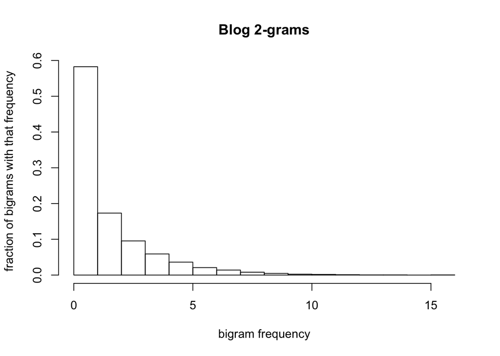

To answer the question about how many words are needed to cover a certain percentage of the corpus, I follow the recommendation in one of the threads in the discussion forums. In a frequency-sorted dictionary, one would need approximately 156,000 words to include 50% of words found in the corpus, and approximately 280,000 words in the dictionary to include 90% of the words in the corpus.

### Conclusion

As you can see, the vast majority of words and n-grams in the corpus occur very infrequently. The most frequent 1,000 bigrams account for over 20% of all bigrams found in the corpus, while trigrams are much more spread out.